# Hidden Markov Models - Tutorial

Honours Time Series

Published

October 2026

## Question 1

1. Simulate data (20 observations) from the following three-state HMM. All three state distributions are two-dimensional Gaussian (Figure 5 in Notes):

$$[x_t | z_t = k, \theta] \sim N(\mu_k, \Sigma_k)$$

with transition probability matrix

$$\Gamma = \begin{pmatrix} 0.8 & 0.1 & 0.1 \\
0.1 & 0.8 & 0.1 \\
0.1 & 0.1 & 0.8 \end{pmatrix}$$

R library `SimDesign` has a nice function for simulating multivariate normal values (`rmvnorm`). Here is some code to define the means and variances of the three state distributions:

```r
mu = 10 * matrix(c(-1,0,1,0,0,1), ncol = 2, byrow = TRUE)

sf = 10    # scaling factor

sigma[,,1] = sf* matrix(c(1,1/2,1/2,1), nrow = 2)
sigma[,,2] = sf*matrix(c(1,-1/2,-1/2,1), nrow = 2)
sigma[,,3] = sf*matrix(c(3,0,0,1/2), nrow = 2)
```

R’s `sample` function allows to sample values according to predefined probabilities.

2. Plot the observations $Y_t$, colour-code by true state. Also indicate the path of these observations (as this is a time series).
3. If you would have to estimate parameters for this situation, given only the observations, what are the parameters, and how many are there?

## Question 2

The following are 10 observations from a three-state HMM, with states A, B, C, and possible observations x, y, z (words).

```r
[1] "x" "x" "x" "x" "x" "x" "x" "z" "z" "y"
```

Use the following initial state probabilities, transition probability matrix and emission probability matrix:

```r
init <- c(0.4, 0.3, 0.3)
tpm <- matrix(c(0.5, 0.3, 0.2, 0.1, 0.6, 0.3, 0.2, 0.2, 0.6), byrow = TRUE, ncol = 3)
emmprob <- matrix( c(0.6, 0.2, 0.2, 0.1, 0.5, 0.4, 0.3, 0.3, 0.4), byrow = TRUE, ncol = 3)
```

1. Use the Viterbi algorithm to find the most likely state sequence, given the above observations.
2. Briefly explain and illustrate your results.
3. The true state sequence is

```
 [1] "A" "C" "A" "A" "A" "A" "A" "B" "B" "B"
```

## Question 3

Consider a stationary two-state Poisson-HMM with parameters

$$\Gamma = \begin{pmatrix} 0.1 & 0.9 \\ 0.4 & 0.6 \end{pmatrix}$$

and $\lambda = (1, 3).$

In each of the following ways, compute the probability that the first three observations from this model are 0, 2, 1.

a.) Consider all possible sequences of states of the Markov chain that could have occurred. Compute the probability of each sequence, and the probability of the observations given each sequence.

b.) Apply the formula

$$Pr(X_1 = 0, X_2 = 2, X_3 = 1) = \delta \mathbf{P}(0) \Gamma \mathbf{P}(2) \Gamma \mathbf{P}(1) \mathbf{1}'.$$

## Question 4

We have the general expression

$$L_T = \delta \mathbf{P}(x_1) \Gamma \mathbf{P}(x_2) \ldots \Gamma \mathbf{P}(x_T) \mathbf{1}'$$

for the likelihood of an HMM, e.g. of Poisson type. Consider the special case in which the Markov chain degenerates to a sequence of independent random variables, i.e. an independent mixture model.

Show that, in this case, the likelihood simplifies to

$$L_T(\theta_1, ... \theta_m, \delta_1, \ldots, \delta_m) = \prod_{j=1}^n \sum_{i=1}^m \delta_i p_i(x_j, \theta_i )$$

## Question 5

1. Consider a data set consisting of the following string of 160 symbols from the alphabet {A,B,C}: AABBBACABBBACAAAAAAAAABBBACAAAAABACAAAAAABBBBAC AAAAAAAAAAAABACABACAABBACAAABBBBACAAABACAAAABAC AABACAAABBACAAAABBBBACABBACAAAAAABACABACAAABACA ABBBACAAAABACABBACA15

   Look carefully at the above string. Having analysed the string, describe an HMM model for it. Your description should include the number of states in the HMM,the transition matrix including the values of the elements of the matrix, the emission matrix including the values of its elements, and the initial state probabilities.You need to provide some description/justification for how you arrived at these numbers. I am not expecting you to code the HMM algorithm — you should be able to answer this question just by examining the sequence carefully.
2. Do the same thing (build and justify an HMM model) for the following string of 60 symbols from the alphabet {A,B,C,D,E,F}: CEFBAFCEFBAFBAFCEFCADCAFBEFCEFBEFBEFCAFCEDCAFBEDCADBAFCAFCEF

## Question 6: The Occasionally Dishonest Casino

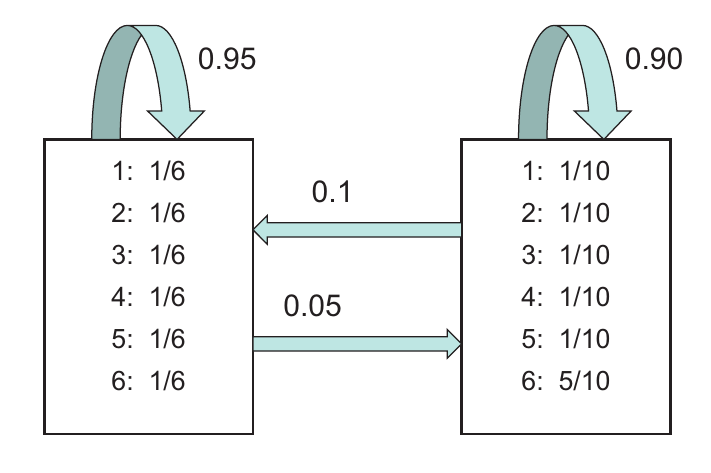

Simulate values from this HMM.

## Question 7: Two-state Bernoulli HMM

Assume a two-state Bernoulli HMM defined as follows:

Transition probability matrix:

$$\Gamma = \begin{pmatrix} 0.5 & 0.5 \\ 0.25 & 0.75 \end{pmatrix}$$

state-dependent distributions given by:

$$P(X_t = x| C_t = 1) = 0.5 \qquad \mbox{for } x = 0, 1$$

and
$$P(X_t = 1| C_t = 2) = 1$$

stationary distribution = $\delta = \frac{1}{3} (1, 2)$

Find $P(0), P(1)$.

Write a function to calculate the likelihood.

Check: $L()$ for observations $(X_1 = 1, X_2 = 1, X_3 = 1) = 29/48$.

## Question 8: Earth-quake data

Fit a two-state Poisson HMM model to the earthquake data (earthquakes.csv).

First write a function for the likelihood function and optimize this to fit the model.

Then use package `depmixS4` to do the same.

## Example: `depmixS4`

This data set is a bivariate series of response times and accuracy scores of a single participant switching between slow/accurate responding and fast guessing on a lexical decision task. The slow and accurate responding, and the fast guessing can be modelled using two states, with a switching regime between them. The dataset further contains a third variable called Pacc, representing the relative pay-off for accurate responding, which is on a scale of zero to one. The value of Pacc was varied during the experiment to induce the switching. This data set is a from participant A in experiment 1a from Dutilh et al (2011).

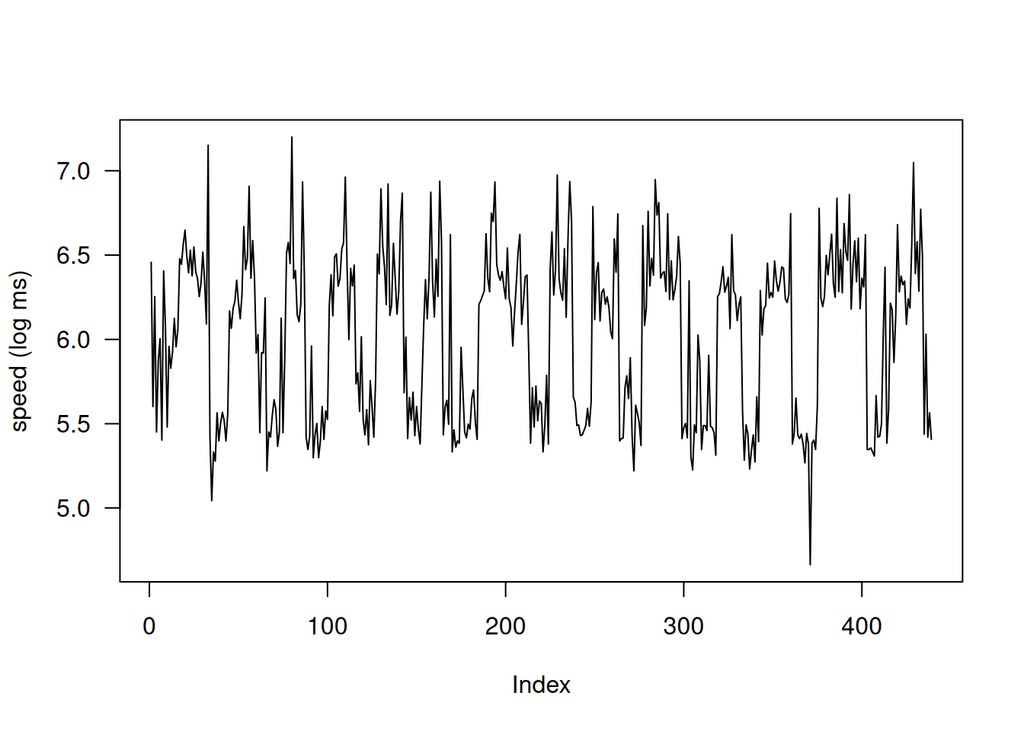

```r
library(depmixS4)

data("speed")
plot(speed$rt, type = "l", las = 1, ylab = "speed (log ms)")
```

```r
set.seed(1)
mod <- depmix(response = rt ~ 1, data = speed,
              nstates = 2, trstart = runif(4))

fm <- fit(mod, emc = em.control(rand=FALSE))
```

```
converged at iteration 68 with logLik: -88.73058
```

```r
fm
```

```
Convergence info: Log likelihood converged to within tol. (relative change)
'log Lik.' -88.73058 (df=7)
AIC:  191.4612
BIC:  220.0527
```

```r
summary(fm)
```

```
Initial state probabilities model
pr1 pr2
  1   0

Transition matrix
        toS1  toS2
fromS1 0.916 0.084
fromS2 0.116 0.884

Response parameters
Resp 1 : gaussian
    Re1.(Intercept) Re1.sd
St1           6.385  0.244
St2           5.510  0.192
```

**Viterbi**

```r
head(fm@posterior)
```

```
  state          S1         S2
1     1 1.000000000 0.00000000
2     2 0.052971914 0.94702809
3     1 0.993964870 0.00603513
4     2 0.005906109 0.99409389
5     2 0.063272479 0.93672752
6     2 0.456540897 0.54345910
```

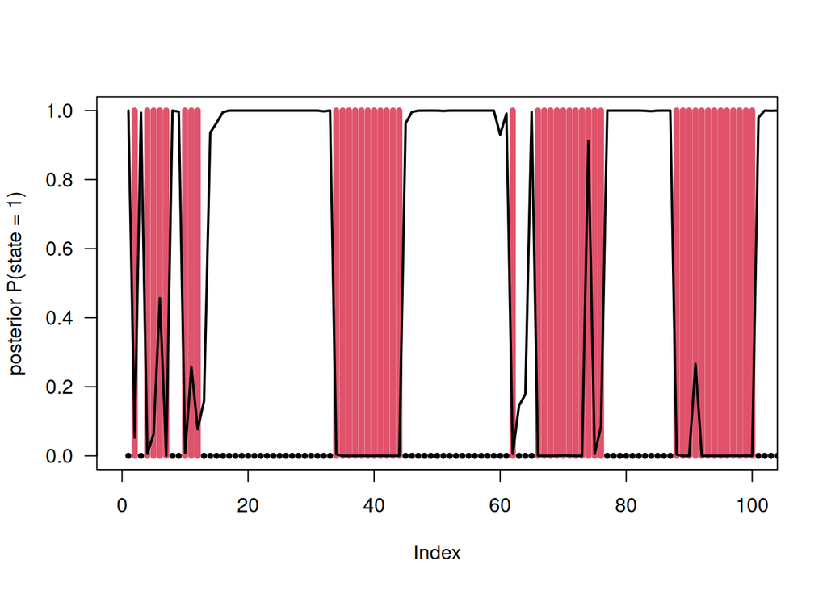

Results from Viterbi algorithm on speed data after fitting a 2-state Gaussian HMM. Red bars: where system is estimated to be in state 2. Black line: posterior probability of state 1.

```r
## viterbi(fm)  ## equivalent

plot(fm@posterior$state-1, type = "h", col = fm@posterior$state,
     xlim = c(0, 100), lwd = 5,
     las = 1, ylab = "posterior P(state = 1)")

lines(fm@posterior$S1, lwd = 2)
```